# Self-medication with antibiotics in Serbian primary-care attenders

Dataset 1: Antibiotic knowledge and self-medication in Serbia

RSR feasibility analysis

2026-08-03

# Introduction

Self-medication with antibiotics — taking them without a prescription, keeping leftovers for the next illness, or asking a pharmacist directly — is one of the main routes by which antibiotics reach people who do not need them, and it is common across south-eastern Europe. These data come from a cross-sectional questionnaire survey of 500 adults who consulted general practitioners at four health centres in Serbia, reported by Horvat and colleagues (*PLOS ONE* 2017;12(7):e0180799). Just over half the sample (252/500, 50%) met the study’s definition of self-medication. Identifying who does it is the first step in deciding whom stewardship programmes should target.

**Aim.** Among Serbian adults attending primary care, we examined which of age group, sex, education, employment status, frequency of GP contact and having a health professional in the family are independently associated with self-medication with antibiotics, mutually adjusting for the others.

This is a *Purpose 3* analysis: several predictors are of interest and the question is which remain associated with the outcome after mutual adjustment.

# Methods

**Data source.** Cross-sectional, interviewer-administered questionnaire survey of adults consulting general practitioners at four Serbian health centres; 500 respondents completed the entire questionnaire and all 500 are analysed here. All measurements were taken on a single occasion, so exposure and outcome were recorded at the same moment.

**Variables.** The outcome is `self_medication`, a binary indicator; the modelled event is **self-medication = yes** under the source paper’s definition (252 events, 248 non-events, so the rarer class has 248). Predictors are `age_group` (six bands; reference: over 65, the largest band at n = 123), `sex` (reference: female, n = 304), `education_level` (primary / secondary / tertiary; reference: secondary, the largest group at n = 259), `employment_status` (reference: employed, n = 251), `gp_visits_past_year` (four bands of visits in the previous 12 months; reference: none, the group with no primary-care contact, n = 135) and `health_professional_in_family` (reference: no, n = 374). All six are categorical, so every estimate is an odds ratio against the stated reference level; the file contains no continuous predictors at all.

Two of the eight available background variables were left out deliberately. `marital_status` is largely a restatement of age here (Cramér’s V = 0.55 with `age_group`), so it would consume two parameters and inflate the variance of the age contrasts without adding a distinct construct. `household_size` is unrelated to the outcome (univariable p = 0.937) and has no plausible mechanism. `id` is a row number and is never modelled.

The two knowledge variables in this file are also excluded, on different grounds. `knowledge_score` and `adequate_knowledge` are the same quantity measured twice — the latter is exactly the indicator `knowledge_score >= 9`, which re-deriving from the score reproduces exactly (`identical()` returns TRUE) — so at most one of them could ever enter a model, and never both. More importantly, neither is a *background characteristic*: knowledge is on the causal pathway between education and behaviour, and its association with self-medication is exactly what the source paper set out to test. Including it here would change the question from “who self-medicates?” to “does knowledge explain self-medication over and above demography?”, which is a different analysis with a mediation structure. This document keeps to the demographic question.

**Statistical analysis.** Logistic regression (`glm(family = binomial)`), justified because the outcome is binary. We fitted a univariable model for each predictor first, then a single multivariable model containing all of them. Predictors were chosen in advance on subject-matter grounds, not by significance. Estimates are odds ratios with 95% confidence intervals; significance threshold 0.05. Assumptions were checked with `performance::check_model()`, with attention to binned residuals, collinearity and influential observations rather than to normality or constant variance, which do not apply to a logistic model. Analysis used R version 4.6.0 (2026-04-24) with tidyverse, gtsummary and performance.

**Missing data.** There is none. Every one of the 12 columns is 100% complete, so the model uses all 500 of 500 rows and 0 were dropped. There is no missing-data story to tell for this file — though the survey kept only respondents who completed the whole questionnaire, so partial responders were excluded before the data reached us and nothing is known about them.

# Results

## Sample characteristics

**Table 1. Sample characteristics, by self-medication status.**

| **Characteristic** | **N** | **Overall** N = 500<sup>1</sup> | **No self-medication** N = 248<sup>1</sup> | **Self-medicated** N = 252<sup>1</sup> |
| --- | --- | --- | --- | --- |
| age_group | 500 |  |  |  |
| Over 65 |  | 123 (25%) | 51 (21%) | 72 (29%) |
| 18-24 |  | 25 (5.0%) | 17 (6.9%) | 8 (3.2%) |
| 25-34 |  | 78 (16%) | 50 (20%) | 28 (11%) |
| 35-44 |  | 70 (14%) | 32 (13%) | 38 (15%) |
| 45-54 |  | 104 (21%) | 49 (20%) | 55 (22%) |
| 55-64 |  | 100 (20%) | 49 (20%) | 51 (20%) |
| sex | 500 |  |  |  |
| Female |  | 304 (61%) | 146 (59%) | 158 (63%) |
| Male |  | 196 (39%) | 102 (41%) | 94 (37%) |
| education_level | 500 |  |  |  |
| Secondary |  | 259 (52%) | 117 (47%) | 142 (56%) |
| Primary |  | 38 (7.6%) | 12 (4.8%) | 26 (10%) |
| Tertiary |  | 203 (41%) | 119 (48%) | 84 (33%) |
| employment_status | 500 |  |  |  |
| Employed |  | 251 (50%) | 131 (53%) | 120 (48%) |
| Unemployed |  | 114 (23%) | 50 (20%) | 64 (25%) |
| Pensioner |  | 135 (27%) | 67 (27%) | 68 (27%) |
| gp_visits_past_year | 500 |  |  |  |
| None |  | 135 (27%) | 78 (31%) | 57 (23%) |
| 1-4 |  | 223 (45%) | 102 (41%) | 121 (48%) |
| 5-10 |  | 72 (14%) | 32 (13%) | 40 (16%) |
| More than 10 |  | 70 (14%) | 36 (15%) | 34 (13%) |
| health_professional_in_family | 500 | 126 (25%) | 62 (25%) | 64 (25%) |

<sup>1</sup> n (%)

The two groups are close to equal in size and differ mainly on age and education. Self-medicators are older (29% are over 65, against 21% of non-self-medicators) and less likely to hold a tertiary degree (33% versus 48%). Sex, employment, GP attendance and having a health professional in the family look almost identical in the two groups.

## Exploratory figure

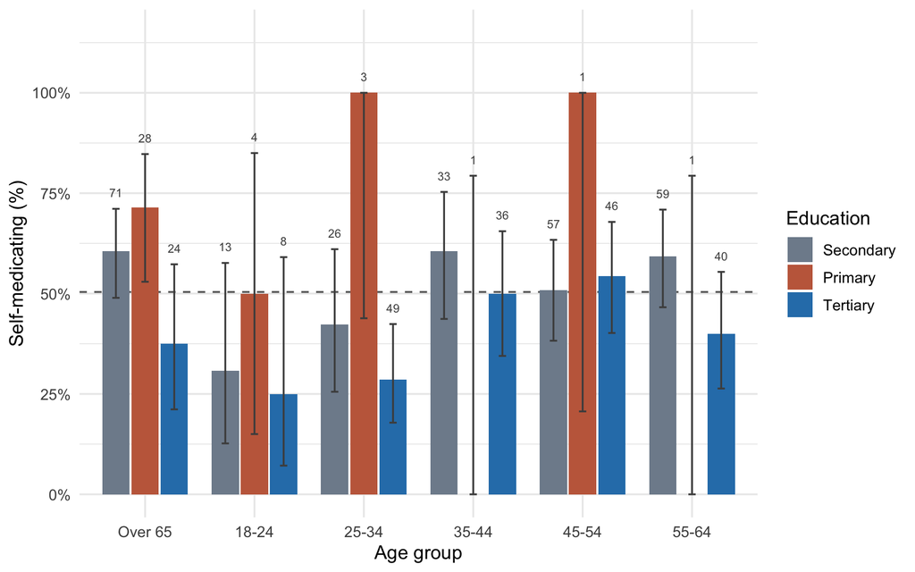

Figure 1. Proportion of respondents reporting self-medication with antibiotics, by age group and education level. Error bars are 95% Wilson intervals for the proportion; the number above each bar is the group size. The dashed line is the overall prevalence.

Self-medication rises with age and falls with education, but the two work against each other and several age-by-education cells contain only a handful of people (the primary-education bars below age 65 rest on one to four respondents each), so the crude picture is unstable and the confidence intervals in those cells are uninformative.

## Univariable models

| **Characteristic** | **N** | **OR** | **95% CI** | **p-value** |
| --- | --- | --- | --- | --- |
| age_group | 500 |  |  |  |
| Over 65 |  | — | — |  |
| 18-24 |  | 0.33 | 0.13, 0.81 | 0.018 |
| 25-34 |  | 0.40 | 0.22, 0.71 | 0.002 |
| 35-44 |  | 0.84 | 0.47, 1.52 | 0.6 |
| 45-54 |  | 0.80 | 0.47, 1.35 | 0.4 |
| 55-64 |  | 0.74 | 0.43, 1.25 | 0.3 |
| sex | 500 |  |  |  |
| Female |  | — | — |  |
| Male |  | 0.85 | 0.59, 1.22 | 0.4 |
| education_level | 500 |  |  |  |
| Secondary |  | — | — |  |
| Primary |  | 1.79 | 0.88, 3.81 | 0.12 |
| Tertiary |  | 0.58 | 0.40, 0.84 | 0.004 |
| employment_status | 500 |  |  |  |
| Employed |  | — | — |  |
| Unemployed |  | 1.40 | 0.90, 2.19 | 0.14 |
| Pensioner |  | 1.11 | 0.73, 1.69 | 0.6 |
| gp_visits_past_year | 500 |  |  |  |
| None |  | — | — |  |
| 1-4 |  | 1.62 | 1.06, 2.51 | 0.028 |
| 5-10 |  | 1.71 | 0.96, 3.06 | 0.068 |
| More than 10 |  | 1.29 | 0.72, 2.31 | 0.4 |
| health_professional_in_family | 500 |  |  |  |
| No |  | — | — |  |
| Yes |  | 1.02 | 0.68, 1.53 | >0.9 |

Abbreviations: CI = Confidence Interval, OR = Odds Ratio

Only two predictors are associated with self-medication at all. Education is the strongest (p = 0.001): compared with secondary education, tertiary education halves the odds of self-medicating (OR 0.58 (95% CI 0.40 to 0.84, p = 0.004)), while the small primary-education group runs the other way (OR 1.79 (95% CI 0.88 to 3.81, p = 0.118)). Age is the other (p = 0.015): every younger band self-medicates less than the over-65s, most clearly the 18-24 group (OR 0.33 (95% CI 0.13 to 0.81, p = 0.018)) and the 25-34 group (OR 0.40 (95% CI 0.22 to 0.71, p = 0.002)), though the youngest band contains only 25 people. The remaining four are null as whole variables: sex (p = 0.381), employment status (p = 0.336), GP visits (p = 0.121) and having a health professional in the family (p = 0.919), the last of these almost perfectly flat (OR 1.02 (95% CI 0.68 to 1.53, p = 0.919)). One caveat on GP visits: although the variable as a whole is not associated, the single contrast of 1-4 visits against none is nominally significant (OR 1.62 (95% CI 1.06 to 2.51, p = 0.028)) with no gradient across the higher bands, which is the pattern one expects from multiple testing across four levels rather than a real dose-response.

## Why adjustment is needed

The two predictors that do show a crude association are entangled with each other and with a third variable, so neither crude estimate can be read at face value. `age_group` confounds the education association: 28 of the 38 primary-educated respondents (74%) are over 65, because schooling expanded in the region within these respondents’ lifetimes, and age is independently associated with self-medicating; so part of what looks like an education effect is the age composition of the education groups, and part of the crude age effect is really the lower education of the older bands. `employment_status` is the second: 100 of the 135 pensioners (74%) are over 65 (Cramér’s V with age = 0.58), and pensioner status is also tied to income and to what people can afford to do about an infection, so leaving it out risks attributing an income effect to age. `gp_visits_past_year` is a third and more awkward case: older and less educated respondents attend far more often (62% of the over-65s report five or more visits, against 18% of everyone else), so any crude association between attendance and self-medication would be partly an age association. Fitting all six together turns each estimate into a within-stratum comparison — the education contrast becomes “respondents of the same age, employment status and attendance frequency”, which is the comparison a targeting decision actually requires.

## Multivariable model

| **Characteristic** | **OR** | **95% CI** | **p-value** |
| --- | --- | --- | --- |
| age_group |  |  |  |
| Over 65 | — | — |  |
| 18-24 | 0.16 | 0.05, 0.48 | 0.001 |
| 25-34 | 0.29 | 0.12, 0.67 | 0.004 |
| 35-44 | 0.60 | 0.25, 1.39 | 0.2 |
| 45-54 | 0.56 | 0.25, 1.23 | 0.2 |
| 55-64 | 0.59 | 0.29, 1.17 | 0.14 |
| sex |  |  |  |
| Female | — | — |  |
| Male | 0.86 | 0.59, 1.27 | 0.5 |
| education_level |  |  |  |
| Secondary | — | — |  |
| Primary | 1.83 | 0.85, 4.11 | 0.13 |
| Tertiary | 0.59 | 0.39, 0.89 | 0.012 |
| employment_status |  |  |  |
| Employed | — | — |  |
| Unemployed | 1.41 | 0.84, 2.39 | 0.2 |
| Pensioner | 0.53 | 0.26, 1.04 | 0.069 |
| gp_visits_past_year |  |  |  |
| None | — | — |  |
| 1-4 | 1.22 | 0.76, 1.95 | 0.4 |
| 5-10 | 1.18 | 0.62, 2.27 | 0.6 |
| More than 10 | 0.83 | 0.42, 1.65 | 0.6 |
| health_professional_in_family |  |  |  |
| No | — | — |  |
| Yes | 1.09 | 0.71, 1.68 | 0.7 |

Abbreviations: CI = Confidence Interval, OR = Odds Ratio

Model fit and events per parameter

| Statistic | Value |
| --- | --- |
| AIC (fitted model) | 686.2 |
| AIC (intercept-only model) | 695.1 |
| Tjur's R-squared | 0.071 |
| Likelihood-ratio test vs null (p) | <0.001 |
| Events (self-medication = yes) | 252 |
| Non-events | 248 |
| Rarer class | 248 |
| Non-intercept parameters | 14 |
| Events per parameter | 17.7 |

With 248 in the rarer outcome class and 14 non-intercept parameters, there are 17.7 events per parameter, comfortably above the conventional minimum of ten, so the model is not overfitted despite the number of factor levels. Adjusting for all six predictors, tertiary education remains independently associated with lower odds of self-medicating (OR 0.59 (95% CI 0.39 to 0.89, p = 0.012)), and the age gradient persists at the young end: conditional on education, employment, attendance and sex, the 18-24 band has OR 0.16 (95% CI 0.05 to 0.48, p = 0.001) and the 25-34 band OR 0.29 (95% CI 0.12 to 0.67, p = 0.004) relative to the over-65s, while the middle bands are no longer distinguishable from the oldest (45-54: OR 0.56 (95% CI 0.25 to 1.23, p = 0.155)). Primary education is not independently associated (OR 1.83 (95% CI 0.85 to 4.11, p = 0.132)), nor is sex (OR 0.86 (95% CI 0.59 to 1.27, p = 0.451)), employment (pensioner: OR 0.53 (95% CI 0.26 to 1.04, p = 0.069)), attendance (more than ten visits: OR 0.83 (95% CI 0.42 to 1.65, p = 0.594)) or family health-care exposure (OR 1.09 (95% CI 0.71 to 1.68, p = 0.684)). The whole model is only marginally better than an intercept alone (AIC 686.2 versus 695.1; likelihood-ratio p < 0.001) and Tjur’s R² is 0.071 — that is, these six background characteristics discriminate self-medicators from non-self-medicators barely at all.

## Unadjusted versus adjusted

**Table 2. Unadjusted and adjusted estimates.**

| **Characteristic** | **Unadjusted** **N** | **Unadjusted** **OR** | **Unadjusted** **95% CI** | **Unadjusted** **p-value** | **Adjusted** **OR** | **Adjusted** **95% CI** | **Adjusted** **p-value** |
| --- | --- | --- | --- | --- | --- | --- | --- |
| age_group | 500 |  |  |  |  |  |  |
| Over 65 |  | — | — |  | — | — |  |
| 18-24 |  | 0.33 | 0.13, 0.81 | 0.018 | 0.16 | 0.05, 0.48 | 0.001 |
| 25-34 |  | 0.40 | 0.22, 0.71 | 0.002 | 0.29 | 0.12, 0.67 | 0.004 |
| 35-44 |  | 0.84 | 0.47, 1.52 | 0.6 | 0.60 | 0.25, 1.39 | 0.2 |
| 45-54 |  | 0.80 | 0.47, 1.35 | 0.4 | 0.56 | 0.25, 1.23 | 0.2 |
| 55-64 |  | 0.74 | 0.43, 1.25 | 0.3 | 0.59 | 0.29, 1.17 | 0.14 |
| sex | 500 |  |  |  |  |  |  |
| Female |  | — | — |  | — | — |  |
| Male |  | 0.85 | 0.59, 1.22 | 0.4 | 0.86 | 0.59, 1.27 | 0.5 |
| education_level | 500 |  |  |  |  |  |  |
| Secondary |  | — | — |  | — | — |  |
| Primary |  | 1.79 | 0.88, 3.81 | 0.12 | 1.83 | 0.85, 4.11 | 0.13 |
| Tertiary |  | 0.58 | 0.40, 0.84 | 0.004 | 0.59 | 0.39, 0.89 | 0.012 |
| employment_status | 500 |  |  |  |  |  |  |
| Employed |  | — | — |  | — | — |  |
| Unemployed |  | 1.40 | 0.90, 2.19 | 0.14 | 1.41 | 0.84, 2.39 | 0.2 |
| Pensioner |  | 1.11 | 0.73, 1.69 | 0.6 | 0.53 | 0.26, 1.04 | 0.069 |
| gp_visits_past_year | 500 |  |  |  |  |  |  |
| None |  | — | — |  | — | — |  |
| 1-4 |  | 1.62 | 1.06, 2.51 | 0.028 | 1.22 | 0.76, 1.95 | 0.4 |
| 5-10 |  | 1.71 | 0.96, 3.06 | 0.068 | 1.18 | 0.62, 2.27 | 0.6 |
| More than 10 |  | 1.29 | 0.72, 2.31 | 0.4 | 0.83 | 0.42, 1.65 | 0.6 |
| health_professional_in_family | 500 |  |  |  |  |  |  |
| No |  | — | — |  | — | — |  |
| Yes |  | 1.02 | 0.68, 1.53 | >0.9 | 1.09 | 0.71, 1.68 | 0.7 |

Abbreviations: CI = Confidence Interval, OR = Odds Ratio

Three sets of estimates move meaningfully, and they move in different directions. The age contrasts move *away* from the null and strengthen: the 18-24 band goes from OR 0.33 (95% CI 0.13 to 0.81, p = 0.018) crude to OR 0.16 (95% CI 0.05 to 0.48, p = 0.001) adjusted, and 25-34 from OR 0.40 (95% CI 0.22 to 0.71, p = 0.002) to OR 0.29 (95% CI 0.12 to 0.67, p = 0.004). This is negative confounding by education: young respondents are much better educated than the over-65s and education protects, so the crude age comparison *understated* how much lower self-medication is in the young. Employment status moves the same way and further: the crude pensioner estimate is essentially null (OR 1.11 (95% CI 0.73 to 1.69, p = 0.631)) but adjusted it becomes OR 0.53 (95% CI 0.26 to 1.04, p = 0.069) — pensioners look like everyone else until age is held constant, at which point they self-medicate *less* than employed people of the same age, a borderline suppression effect that should not be over-read given its width and that it never crosses 0.05. The GP-visit estimates move the opposite way, *towards* the null, and produce the only loss of significance in the table: 1-4 visits versus none falls from OR 1.62 (95% CI 1.06 to 2.51, p = 0.028) to OR 1.22 (95% CI 0.76 to 1.95, p = 0.405). That crude excess was age and education — frequent attenders are older and less educated — and once those are held constant, attendance carries nothing.

Three estimates barely move at all, and they are the informative ones. Tertiary education is almost unchanged (OR 0.58 (95% CI 0.40 to 0.84, p = 0.004) to OR 0.59 (95% CI 0.39 to 0.89, p = 0.012)), which says the education effect is not an age effect in disguise; primary education is likewise essentially static (OR 1.79 (95% CI 0.88 to 3.81, p = 0.118) to OR 1.83 (95% CI 0.85 to 4.11, p = 0.132)) and non-significant in both columns, despite three-quarters of that group being over 65 — the two confounding routes evidently cancel. Sex (OR 0.85 (95% CI 0.59 to 1.22, p = 0.381) to OR 0.86 (95% CI 0.59 to 1.27, p = 0.451)) and family health-care exposure (OR 1.02 (95% CI 0.68 to 1.53, p = 0.919) to OR 1.09 (95% CI 0.71 to 1.68, p = 0.684)) are flat and null throughout. In summary: two age contrasts gain strength, one GP-visit contrast loses significance, and the education result is robust to adjustment.

## Diagnostics

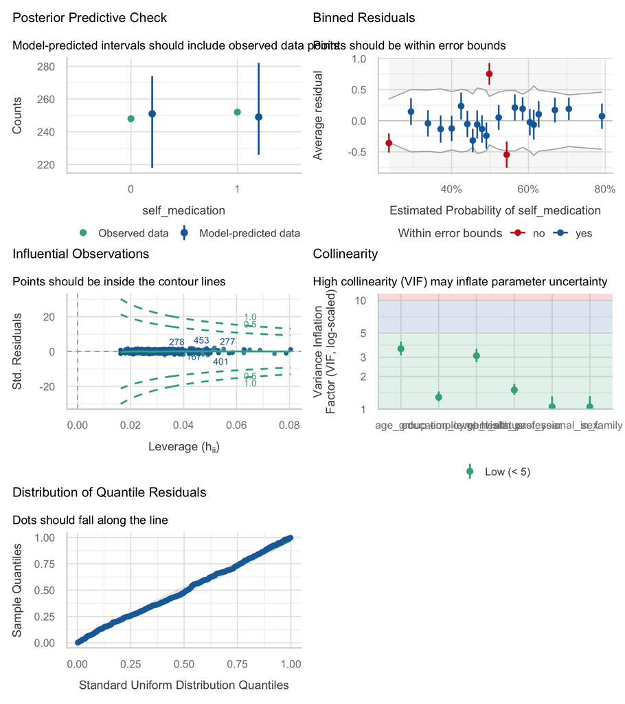

[output not shown]

[output cut: 12 more lines]

| Term | VIF | VIF_CI_low | VIF_CI_high | SE_factor | Tolerance | Tolerance_CI_low | Tolerance_CI_high |
| --- | --- | --- | --- | --- | --- | --- | --- |
| age_group | 3.600034 | 3.125061 | 4.181168 | 1.136660 | 0.2777752 | 0.2391676 | 0.3199938 |
| sex | 1.050898 | 1.008155 | 1.317679 | 1.025133 | 0.9515668 | 0.7589103 | 0.9919111 |
| education_level | 1.287919 | 1.181214 | 1.457455 | 1.065300 | 0.7764466 | 0.6861275 | 0.8465869 |
| employment_status | 3.099711 | 2.702883 | 3.589012 | 1.326876 | 0.3226108 | 0.2786282 | 0.3699753 |
| gp_visits_past_year | 1.501747 | 1.357920 | 1.703370 | 1.070121 | 0.6658912 | 0.5870715 | 0.7364207 |
| health_professional_in_family | 1.052393 | 1.008802 | 1.311863 | 1.025862 | 0.9502150 | 0.7622747 | 0.9912746 |

# Discussion

**Future work.** A study that records the *source* of the antibiotic (leftover stock, pharmacy without prescription, family member) alongside attendance would separate the two competing explanations for the null GP-visit association.

# Feasibility notes

*Not part of a student report.*

- **Usable but weak, and the weakest of the three outcomes in this file.** The outcome is beautifully balanced (252 versus 248, 50% prevalence) and 100% complete, so there is no separation, no sparse-outcome problem and 17.7 events per parameter. What it lacks is signal: Tjur’s R² = 0.071, AIC 686.2 against 695.1 for the null model, and only two of six predictors reach significance.
- **MAJOR: the binned-residuals check fails** (86% within bounds, want 95%+). Students who run `check_model()` will get a red flag and there is no fix available to them — the model genuinely does not fit, because the predictors do not discriminate. Worth deciding in advance whether that is a teachable moment or an unfair trap.
- **Complete-case N = 500** of 500; 0 dropped. The file is 100% complete, so there is no missing-data narrative to write and students should be told to say so plainly rather than invent one.
- **`gp_visits_past_year` is bidirectional** with respect to this outcome (self-medicating may reduce GP contact, or frequent GP contact may supply the leftover antibiotics). It is null here, so nothing turns on it statistically, but any student who writes a causal sentence about it is wrong. This makes `self_medication` the better of the three outcomes for teaching reverse causation and the worse one for teaching effect estimation.
- **The knowledge trap applies here too, in a subtler form.** Neither `knowledge_score` nor `adequate_knowledge` can be used as a predictor without turning this into a mediation analysis (knowledge sits between education and behaviour), and they can never both be used because `adequate_knowledge` is exactly `knowledge_score >= 9`. Students will be tempted, because the crude difference is real: self-medicators average 8.28 points against 9.35 for the rest.
- **Sparse cells in two contrasts.** The 18-24 band has only 25 respondents (8 events) and the primary-education group only 38 (26 events). Not sparse enough to break the fit, but enough that a student using 18-24 as the age reference level — the obvious choice — gets confidence intervals up to twenty-fold wide. Setting the reference to the largest band (over 65) fixes this and is worth flagging explicitly.
- **All predictors are categorical**, so no analysis of this file can demonstrate a per-unit odds ratio, and the `check_model()` linearity panel is meaningless.
- **Collinearity is present but tolerable**: max VIF 3.60 (age_group), from the age-employment overlap (74% of pensioners are over 65; Cramér’s V 0.58). Adding `marital_status` makes it worse for no gain.